# Population and samples in statistics

## Libraries and settings

```python
# Libraries
import os
import numpy as np
import random
import statistics
import matplotlib.pyplot as plt
from IPython.display import Image

# Ignore warnings
import warnings
warnings.filterwarnings("ignore")

# Show current working directory
print(os.getcwd())
```

```
/workspaces/data_analytics/Week_06
```

## Chickens on a chicken farm (simulated data)

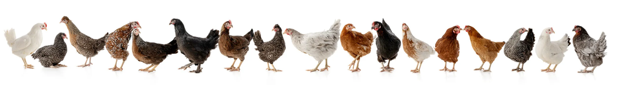

```python
Image("chickens.png", width=800)
```

```
25000
2800.2133
239.6411
```

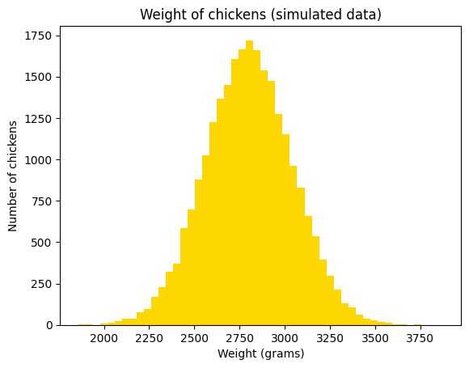

```python
# Parameters of distribution
p_mean = 2800
p_std = 240
p_n = 25000

# Setting a seed to restore the random numbers later
np.random.seed(42)

# Generate (normally distributed) data with mean = 2800 g and standard deviation = 240 g
pop = np.random.normal(loc=p_mean, scale=p_std, size=p_n)
print(f'{len(pop):.0f}')
print(f'{np.mean(pop):.4f}')
print(f'{np.std(pop):.4f}')

# Plot histogram based on the data
plt.hist(pop, bins = 50, color='gold')
plt.title('Weight of chickens (simulated data)')
plt.xlabel('Weight (grams)')
plt.ylabel('Number of chickens')

plt.show()
```

## Single random sample from the population

```
Mean: 2789.9416
Standard deviation: 255.3321
```

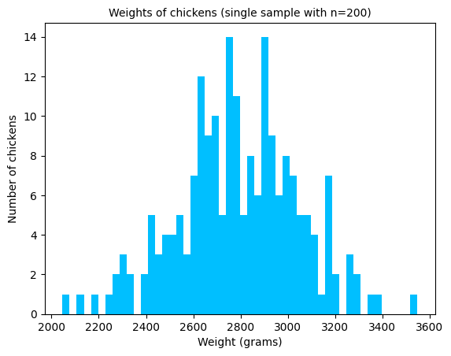

```python
# Sample size
sample_size = 200

# Set random seed for reproducibility
random.seed(42)

# Random sample from the population (without replacement)
random_sample = random.sample(list(pop), sample_size)

# Statistics of the sample
print(f'Mean: {statistics.mean(random_sample):.4f}')
print(f'Standard deviation: {statistics.stdev(random_sample):.4f}')

# Plot histogram based on the sample
plt.hist(random_sample, bins = 50, color='deepskyblue')
plt.title(f'Weights of chickens (single sample with n={sample_size})', fontsize=10)
plt.xlabel('Weight (grams)')
plt.ylabel('Number of chickens')

plt.show()
```

## Repeated random sampling 'with replacement' (bootstrapping)

```
180.0185
24.9668
```

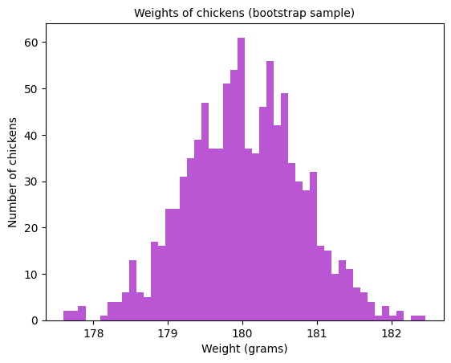

```python
def bootstrap(p_mean = 2800, p_std = 240, p_n =25000, num_iter = 5000, sample_size = 200):
    """
    Creates bootstrap sample from a distribution.

    :param p_mean population mean. Type = int, float
    :param p_std: Type = int, float
    :param p_n: Type = int, float
    :param num_iter: number of iterations. Type = int
    :param sample_size: size of single bootstrap sample. Type = int
    :return: plot of bootstrap sample.
    """

    # Setting a seed to restore the random numbers later
    np.random.seed(42)

    # Generate (normally distributed) data
    pop = np.random.normal(loc=p_mean, scale=p_std, size=p_n)

    # Create empty lists to save results of iterations
    sample_mean = []
    sample_std  = []

    # Loop for iterations
    for i in range(num_iter):
        samp = np.random.choice(pop, size=sample_size, replace=True)
        avg = np.mean(samp)
        std = np.std(samp)
        sample_mean.append(avg)
        sample_std.append(std)

    # Print mean and sd of bootsstapped distribution
    print(f'{np.mean(sample_mean):.4f}')
    print(f'{np.mean(sample_std):.4f}')

    # Plot histogram based on the bootstrapped data
    plt.hist(sample_mean, bins = 50, color='mediumorchid')
    plt.title('Weights of chickens (bootstrap sample)', fontsize=10)
    plt.xlabel('Weight (grams)')
    plt.ylabel('Number of chickens')
    plt.show()

# Function call
bootstrap(p_mean=180, p_std=25, num_iter = 1000, sample_size = 1000)
```

## Varying sample size and number of repeated samples

The code below repeats drawing samples from the population for different `sample_size` values and different numbers of repeated samples (`repeats`). Each subplot shows the distribution of sample means — compare how the shape (spread and peakedness) changes with sample size and repetition count.

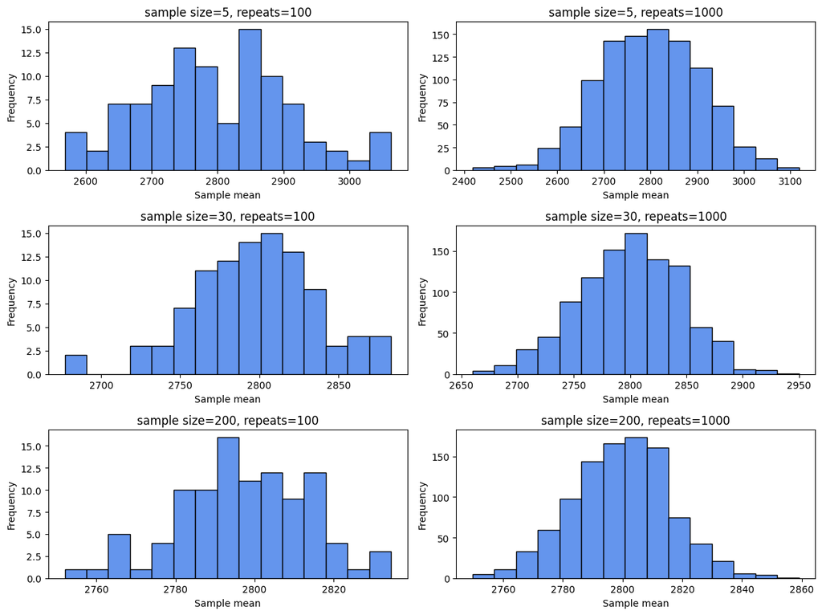

```python
# Repeated sampling: compare distributions of sample means for different sample sizes and repeat counts
import numpy as np
import matplotlib.pyplot as plt

# Ensure 'pop' exists (population created earlier in the notebook). If not, regenerate a representative population:
try:
    pop
except NameError:
    np.random.seed(42)
    pop = np.random.normal(loc=2800, scale=240, size=25000)

sample_sizes = [5, 30, 200]
repeats_list = [100, 1000]
np.random.seed(42)
fig, axes = plt.subplots(len(sample_sizes), len(repeats_list), figsize=(6*len(repeats_list), 3*len(sample_sizes)))
for i, n in enumerate(sample_sizes):
    for j, repeats in enumerate(repeats_list):
        means = [np.mean(np.random.choice(pop, size=n, replace=False)) for _ in range(repeats)]
        ax = axes[i, j] if axes.ndim>1 else axes[max(i,j)]
        ax.hist(means, bins=15, color='cornflowerblue', edgecolor='black')
        ax.set_title(f'sample size={n}, repeats={repeats}')
        ax.set_xlabel('Sample mean')
        ax.set_ylabel('Frequency')

plt.tight_layout()
plt.show()
```

## Varying bootstrap iteration counts

Take a single observed sample (from the population) and compute bootstrap distributions of the mean with different numbers of bootstrap resamples. Compare how the bootstrap histogram stabilizes as the number of resamples increases.

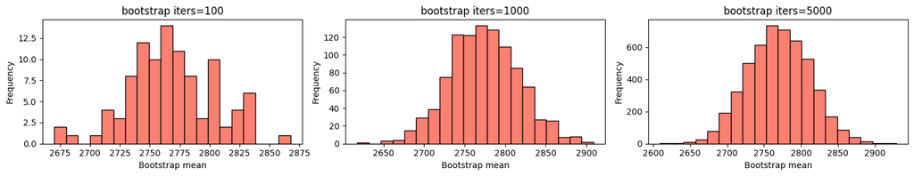

```python
# Bootstrap comparison for different iteration counts
import numpy as np
import matplotlib.pyplot as plt

# Draw a single observed sample from the population (size 30 by default)
np.random.seed(123)
obs_sample = np.random.choice(pop, size=30, replace=False)

bootstrap_iters = [100, 1000, 5000]
fig, axes = plt.subplots(1, len(bootstrap_iters), figsize=(5*len(bootstrap_iters), 3))
for k, iters in enumerate(bootstrap_iters):
    rng = np.random.RandomState(100+k)
    res_means = [np.mean(rng.choice(obs_sample, size=len(obs_sample), replace=True)) for _ in range(iters)]
    ax = axes[k] if hasattr(axes, '__len__') else axes
    ax.hist(res_means, bins=20, color='salmon', edgecolor='black')
    ax.set_title(f'bootstrap iters={iters}')
    ax.set_xlabel('Bootstrap mean')
    ax.set_ylabel('Frequency')

plt.tight_layout()
plt.show()
```

## Practical example: Fuel consumption of small family cars

Below is a small realistic sample (n=30) of fuel consumption measured in liters per 100 km. We compute mean, population and sample standard deviation, and show a histogram + boxplot.

```
n = 30
Mean (L/100km) = 6.747
Population SD = 0.440
Sample SD = 0.448
```

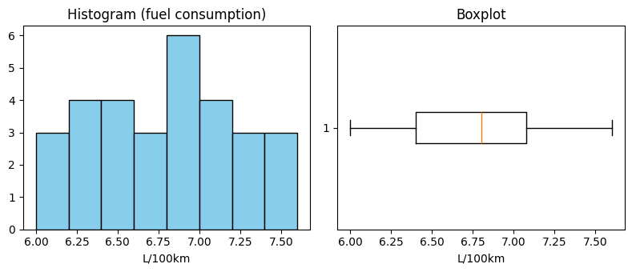

```python
# Sample: fuel consumption (L/100km) of 30 small family cars
data = [6.2,6.5,6.8,7.1,6.9,6.4,7.3,6.0,7.0,6.7,6.6,7.2,6.1,6.3,7.4,7.6,6.8,6.9,7.5,6.2,6.0,7.1,6.5,6.8,6.7,7.0,6.4,6.3,7.2,6.9]
import statistics
import matplotlib.pyplot as plt
import numpy as np

mean = statistics.mean(data)
pop_sd = statistics.pstdev(data)  # population std dev
sample_sd = statistics.stdev(data)  # sample std dev (ddof=1)

print(f'n = {len(data)}')
print(f'Mean (L/100km) = {mean:.3f}')
print(f'Population SD = {pop_sd:.3f}')
print(f'Sample SD = {sample_sd:.3f}')

# Plots: histogram and boxplot
plt.figure(figsize=(8,3.5))
plt.subplot(1,2,1)
plt.hist(data, bins=8, color='skyblue', edgecolor='black')
plt.xlabel('L/100km')
plt.title('Histogram (fuel consumption)')

plt.subplot(1,2,2)
plt.boxplot(data, vert=False)
plt.xlabel('L/100km')
plt.title('Boxplot')

plt.tight_layout()
plt.show()
```

**Interpretation:** The sample mean and standard deviations above are realistic for modern small family cars. With mean ≈ 6.75 L/100km and SD ≈ 0.44, most cars lie roughly between 6.3 and 7.2 L/100km (mean ± 1 SD). I can expand the synthetic dataset or add confidence intervals.

### Expanded synthetic dataset

We generate a larger synthetic sample (n=200) using the sample's mean and standard deviation (for demonstration). This cell prints summary statistics and shows a histogram + boxplot for the expanded dataset.

```
Expanded sample n = 200
Expanded mean = 6.748 L/100km
Expanded sample SD = 0.472 L/100km
```

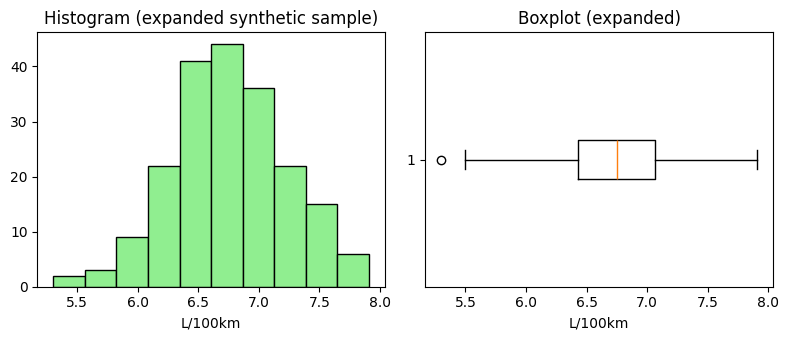

```python
# Expand synthetic dataset based on the observed sample 'data' (n=30)
import numpy as np
import statistics
import matplotlib.pyplot as plt

# Reuse 'data' defined earlier in the notebook
base_mean = statistics.mean(data)
base_sd = statistics.stdev(data)  # use sample SD as estimate of spread

np.random.seed(123)
expanded = np.random.normal(loc=base_mean, scale=base_sd, size=200)

print(f'Expanded sample n = {len(expanded)}')
print(f'Expanded mean = {np.mean(expanded):.3f} L/100km')
print(f'Expanded sample SD = {np.std(expanded, ddof=1):.3f} L/100km')

# Plot histogram and boxplot for expanded sample
plt.figure(figsize=(8,3.5))
plt.subplot(1,2,1)
plt.hist(expanded, bins=10, color='lightgreen', edgecolor='black')
plt.xlabel('L/100km')
plt.title('Histogram (expanded synthetic sample)')

plt.subplot(1,2,2)
plt.boxplot(expanded, vert=False)
plt.xlabel('L/100km')
plt.title('Boxplot (expanded)')

plt.tight_layout()
plt.show()
```

### 95% Confidence intervals for the mean

Compute a t-based 95% confidence interval when `scipy` is available and fall back to a bootstrap percentile CI otherwise. We compute CIs for both the original small sample (`data`, n=30) and the expanded synthetic sample (n=200).

```python
import numpy as np
import statistics
from math import sqrt

def t_based_ci(x, alpha=0.05):
    n = len(x)
    mean = statistics.mean(x)
    s = statistics.stdev(x)
    se = s / sqrt(n)
    try:
        from scipy import stats
        t_crit = stats.t.ppf(1 - alpha/2, df=n-1)
        return (mean - t_crit*se, mean + t_crit*se)
    except Exception:
        return None

def bootstrap_ci(x, alpha=0.05, n_resamples=10000, random_state=42):
    rng = np.random.RandomState(random_state)
    n = len(x)
    res_means = np.empty(n_resamples)
    for i in range(n_resamples):
        samp = rng.choice(x, size=n, replace=True)
        res_means[i] = np.mean(samp)
    lower = np.percentile(res_means, 100*(alpha/2))
    upper = np.percentile(res_means, 100*(1-alpha/2))
    return (lower, upper)

samples = { 'original (n=30)': np.array(data), 'expanded (n=200)': np.array(expanded) }
for name, samp in samples.items():
    n = len(samp)
    mean = np.mean(samp)
    s = np.std(samp, ddof=1)
    print('---')
    print(f'{name}: n={n}, mean={mean:.3f}, sd={s:.3f}')
    tci = t_based_ci(samp)
    if tci is not None:
        print(f'T-based 95% CI: ({tci[0]:.3f}, {tci[1]:.3f})')
    else:
        print('scipy not available — skipping t-based CI')
    bci = bootstrap_ci(samp)
    print(f'Bootstrap 95% CI (percentile): ({bci[0]:.3f}, {bci[1]:.3f})')
```

```
---
original (n=30): n=30, mean=6.747, sd=0.448
T-based 95% CI: (6.579, 6.914)
Bootstrap 95% CI (percentile): (6.590, 6.907)
---
expanded (n=200): n=200, mean=6.748, sd=0.472
T-based 95% CI: (6.682, 6.814)
Bootstrap 95% CI (percentile): (6.683, 6.814)
```

### Jupyter notebook --footer info-- (please always provide this at the end of each notebook)

## Interactive exploration (optional)

Use the widgets below to interactively vary `sample_size`, `repeats`, and number of bootstrap iterations. If `ipywidgets` is not available in your environment the cells will print a short message and still provide the non-interactive code.

```python
# Interactive sampling explorer using ipywidgets
try:
    import ipywidgets as widgets
    from ipywidgets import interact, IntSlider
    import matplotlib.pyplot as plt
    import numpy as np
    import statistics

    # Prepare a population for the fuel-consumption example (based on the earlier sample 'data')
    base_mean = statistics.mean(data)
    base_sd = statistics.stdev(data)
    np.random.seed(2025)
    pop_fc = np.random.normal(loc=base_mean, scale=base_sd, size=10000)

    def plot_sample_means(sample_size=30, repeats=500):
        means = [np.mean(np.random.choice(pop_fc, size=sample_size, replace=False)) for _ in range(repeats)]
        plt.figure(figsize=(6,3))
        plt.hist(means, bins=20, color='steelblue', edgecolor='black')
        plt.title(f'sample size={sample_size}, repeats={repeats}')
        plt.xlabel('Sample mean (L/100km)')
        plt.ylabel('Frequency')
        plt.show()

    interact(plot_sample_means, sample_size=IntSlider(min=2, max=500, step=1, value=30), repeats=IntSlider(min=50, max=2000, step=50, value=500))
except Exception as e:
    print('ipywidgets not available or running in a non-interactive environment.')
    print('To try the interactive explorer, install ipywidgets (pip install ipywidgets) and run this notebook in JupyterLab/Notebook.')
    # Provide a non-interactive example fallback
    import numpy as np
    import matplotlib.pyplot as plt
    np.random.seed(2025)
    pop_fc = np.random.normal(loc=6.747, scale=0.448, size=10000)  # approximate from the sample
    sample_size = 30
    repeats = 500
    means = [np.mean(np.random.choice(pop_fc, size=sample_size, replace=False)) for _ in range(repeats)]
    plt.hist(means, bins=20, color='steelblue', edgecolor='black')
    plt.title(f'Fallback: sample size={sample_size}, repeats={repeats}')
    plt.xlabel('Sample mean (L/100km)')
    plt.ylabel('Frequency')
    plt.show()
```

```
interactive(children=(IntSlider(value=30, description='sample_size', max=500, min=2), IntSlider(value=500, des…
```

```python
# Interactive bootstrap explorer using ipywidgets
try:
    import ipywidgets as widgets
    from ipywidgets import interact, IntSlider
    import numpy as np
    import matplotlib.pyplot as plt

    # observed sample (fuel consumption) is 'data' defined earlier
    obs = np.array(data)

    def plot_bootstrap(iters=1000):
        rng = np.random.RandomState(0)
        res = [np.mean(rng.choice(obs, size=len(obs), replace=True)) for _ in range(iters)]
        plt.figure(figsize=(6,3))
        plt.hist(res, bins=30, color='salmon', edgecolor='black')
        plt.title(f'Bootstrap iterations={iters}')
        plt.xlabel('Bootstrap mean (L/100km)')
        plt.ylabel('Frequency')
        plt.show()

    interact(plot_bootstrap, iters=IntSlider(min=100, max=10000, step=100, value=1000))
except Exception:
    print('ipywidgets not available or running in a non-interactive environment.')
    print('Fallback: running a bootstrap with 1000 iterations and plotting histogram.')
    import numpy as np
    import matplotlib.pyplot as plt
    obs = np.array([6.2,6.5,6.8,7.1,6.9,6.4,7.3,6.0,7.0,6.7,6.6,7.2,6.1,6.3,7.4,7.6,6.8,6.9,7.5,6.2,6.0,7.1,6.5,6.8,6.7,7.0,6.4,6.3,7.2,6.9])
    rng = np.random.RandomState(0)
    res = [np.mean(rng.choice(obs, size=len(obs), replace=True)) for _ in range(1000)]
    plt.hist(res, bins=30, color='salmon', edgecolor='black')
    plt.title('Bootstrap fallback (iters=1000)')
    plt.xlabel('Bootstrap mean (L/100km)')
    plt.ylabel('Frequency')
    plt.show()
```

```
interactive(children=(IntSlider(value=1000, description='iters', max=10000, min=100, step=100), Output()), _do…
```

```python
import os
import platform
import socket
from platform import python_version
from datetime import datetime

print('-----------------------------------')
print(os.name.upper())
print(platform.system(), '|', platform.release())
print('Datetime:', datetime.now().strftime("%Y-%m-%d %H:%M:%S"))
print('Python Version:', python_version())
print('-----------------------------------')
```

```
-----------------------------------
POSIX
Linux | 6.8.0-1030-azure
Datetime: 2025-11-20 11:20:10
Python Version: 3.11.13
-----------------------------------
```